# Exploratory Data Analysis of the Instagram Reach Dataset

EDA, feature engineering, and interpretable classification for high-engagement Instagram posts

Sotiris Kylintireas — 3220098

2026-03-17

## 1 Project Objective

This project analyzes a dataset of 100 Instagram posts to identify the variables most associated with high engagement. The analysis explores the role of follower count and posting age in determining whether a post receives an above-average number of likes, and evaluates this relationship through a logistic regression classifier.

**Variables explored:** `Followers`, `Hours.since.posted`, `Likes`, along with engineered categorical features `time`, `like`, and `high_like`.

**Modeling task:** Binary classification — predicting whether a post falls in the high-engagement category based on follower count and time since posting.

## 2 Why This Project Matters

Engagement prediction is a practical problem for anyone managing social media content. Understanding which factors drive higher engagement allows content creators and analysts to make data-informed decisions about posting strategy. This project demonstrates that simple, interpretable models built on a minimal feature set can already reveal meaningful patterns — a useful baseline before investing in more complex approaches. It also illustrates why thorough exploratory analysis before modeling is important: distributional asymmetries, class imbalance, and variable relationships all affect how results should be interpreted.

## 3 Executive Summary

**Dataset:** 100 Instagram posts, 6 variables after cleaning. **Goal:** Identify engagement patterns and predict high-engagement posts. **Key findings:** Posting age (`Hours.since.posted`) is a stronger predictor than follower count. Posts in the highest time category show notably higher engagement rates. The `Followers` distribution is strongly right-skewed. **Model result:** Trained on 70 posts and evaluated on a held-out test set of 30 — accuracy 83.3%, AUC 0.727. The model outperforms a majority-class baseline (76.7% accuracy), though recall for the high-engagement class remains moderate due to class imbalance.

## 4 Data Inspection

The dataset contains 100 observations and 7 variables. The index column (`S.No`) was removed as it carries no analytical information, leaving 6 variables for analysis.

Variable Overview — Instagram Reach Dataset

| Variable | Type | Description |
| --- | --- | --- |
| USERNAME | Categorical | Instagram account identifier |
| Followers | Numeric | Number of followers at time of post |
| Caption | Text | Post caption text |
| Hashtags | Text | Hashtags used in the post |
| Hours.since.posted | Numeric | Hours elapsed since post publication |
| Likes | Numeric | Number of likes received |

## 5 Feature Engineering

Two new categorical variables were derived from the numeric data:

**`time`** — categorizes `Hours.since.posted` into three groups (2, 3, or 4+ hours), providing a discrete representation of posting age suitable for group comparisons.

**`like`** — divides `Likes` into three engagement tiers using the first and third quartiles (Q1 = 19, Q3 = 46): low (below Q1), medium (Q1–Q3), and high (above Q3).

**`high_like`** — a binary target variable: 1 if a post falls in the top like-tier, 0 otherwise.

Distribution of Time Category Variable

| Time Category | Count | Relative Frequency |
| --- | --- | --- |
| 2 | 57 | 0.57 |
| 3 | 19 | 0.19 |
| 4 | 24 | 0.24 |

Distribution of Binary Engagement Target (high_like)

| Engagement Class | Count | Relative Frequency |
| --- | --- | --- |
| Low/Medium Engagement | 77 | 0.77 |
| High Engagement | 23 | 0.23 |

The target variable is imbalanced: approximately 77% of posts fall in the Low/Medium Engagement class. This imbalance is an important consideration when interpreting classification performance.

## 6 Descriptive Statistics

Descriptive Statistics — Numeric Variables

|  | Variable | Mean | Std. Dev. | Min | Median | Max |
| --- | --- | --- | --- | --- | --- | --- |
| Followers | Followers | 961.96 | 1,014.63 | 11 | 612 | 4,496 |
| Hours.since.posted | Hours.since.posted | 3.46 | 3.39 | 2 | 2 | 24 |
| Likes | Likes | 46.48 | 55.09 | 8 | 29 | 349 |

## 7 Distribution Analysis

The `Followers` variable is strongly right-skewed, as confirmed by both the histogram and the Q-Q plot. Most accounts have relatively few followers, but several outliers with very high follower counts pull the distribution to the right.

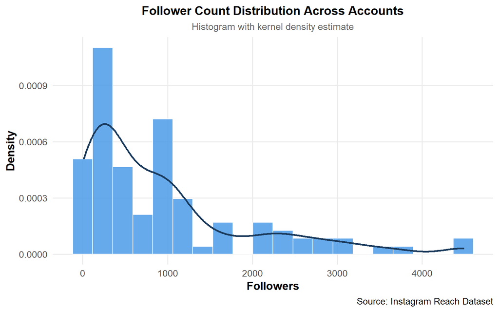

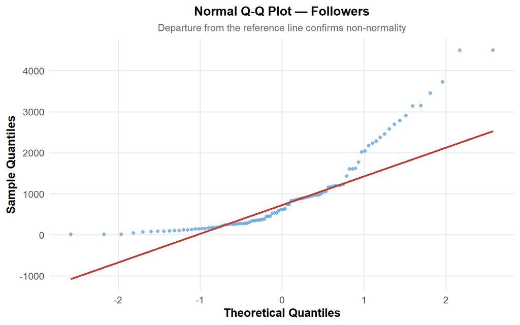

## 8 Time-Based Engagement Analysis

Posts in the highest time category (4+ hours since posting) tend to accumulate more likes, which is consistent with the general positive relationship between posting age and engagement explored in the next section.

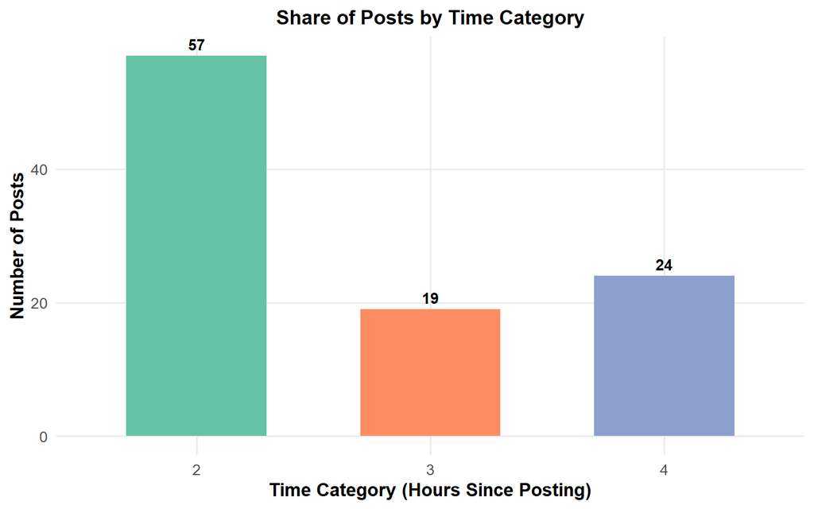

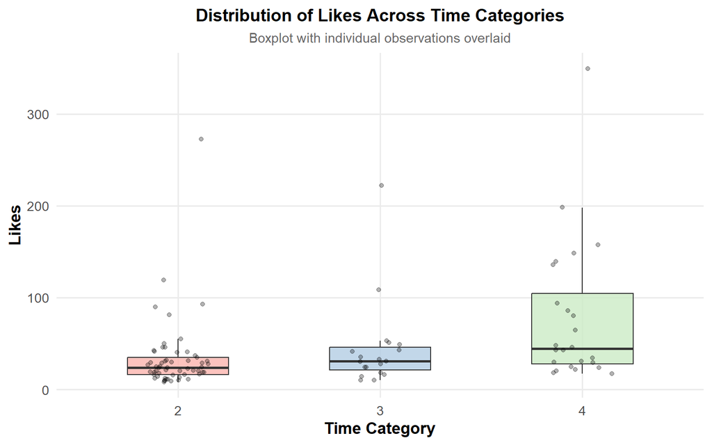

## 9 Correlation and Bivariate Analysis

Pearson Correlation Matrix — Numeric Variables

|  | Followers | Hours.since.posted | Likes |
| --- | --- | --- | --- |
| Followers | 1.000 | 0.251 | 0.266 |
| Hours.since.posted | 0.251 | 1.000 | 0.610 |
| Likes | 0.266 | 0.610 | 1.000 |

There is a moderate positive correlation (r ≈ 0.61) between `Hours.since.posted` and `Likes`, suggesting that posts accumulate more likes as time passes. The relationship between `Followers` and `Likes` is weaker (r ≈ 0.27), indicating that follower count is not the primary driver of engagement in this dataset.

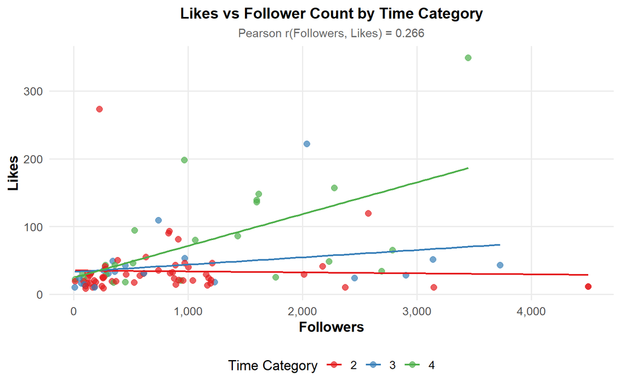

## 10 Categorical Association Analysis

The contingency table and grouped bar chart below show how like categories distribute across time groups. Posts in the highest time category account for a greater share of high-like outcomes.

Contingency Table: Time Category vs Like Category

| Time Category | Low Likes | Medium Likes | High Likes |
| --- | --- | --- | --- |
| 2 | 17 | 33 | 7 |
| 3 | 5 | 9 | 5 |
| 4 | 2 | 11 | 11 |

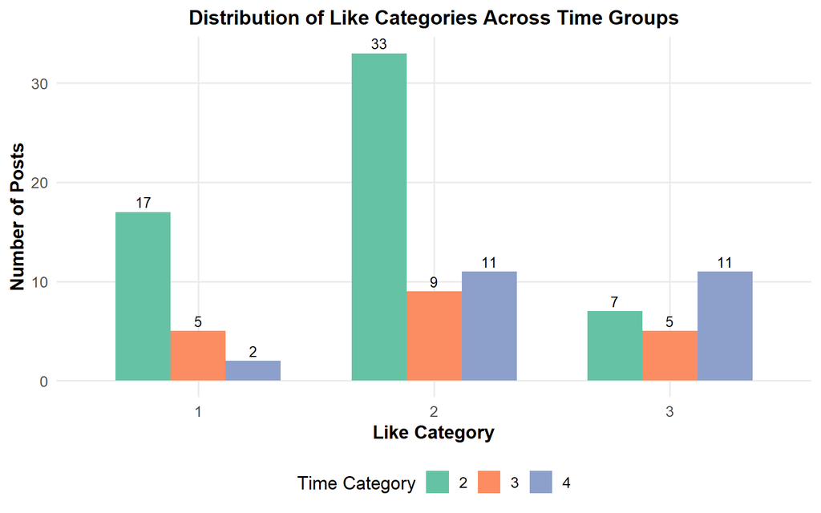

## 11 Logistic Regression Modeling

A binary logistic regression model was trained to predict whether a post achieves high engagement (`high_like = 1`), using `Followers` and `Hours.since.posted` as predictors. The dataset was split into a training set (70 posts) and a held-out test set (30 posts) to allow out-of-sample evaluation.

Logistic Regression Coefficients (fitted on full dataset for display)

| Variable | Estimate | Std. Error | z value | p-value |
| --- | --- | --- | --- | --- |
| (Intercept) | -3.3619 | 0.6487 | -5.1827 | 0.0000 |
| Followers | 0.0004 | 0.0002 | 1.7750 | 0.0759 |
| Hours.since.posted | 0.4859 | 0.1571 | 3.0925 | 0.0020 |

`Hours.since.posted` shows a statistically significant positive effect (p < 0.01): as posting age increases, so does the probability of a post being classified as high-engagement. The effect of `Followers` is weaker and less consistent across observations, confirming that posting age is the most statistically significant predictor in this model.

## 12 Model Evaluation

### 12.1 Confusion Matrix

Confusion Matrix — Logistic Regression (Test Set, n = 30)

|  | Low/Medium Engagement | High Engagement |
| --- | --- | --- |
| 0 | 22 | 4 |
| 1 | 1 | 3 |

The model identifies 3 true high-engagement posts in the test set. It misses 4 high-engagement cases, which explains the relatively modest recall for that class. This pattern is expected given the class imbalance in the data.

### 12.2 Performance Metrics

Model Performance Metrics (Test Set)

| Metric | Value |
| --- | --- |
| Accuracy | 0.8333 |
| Precision | 0.7500 |
| Recall (Sensitivity) | 0.4286 |
| F1-Score | 0.5455 |
| AUC | 0.7267 |
| Baseline Accuracy | 0.7667 |

Although overall accuracy is 83.3%, recall for the high-engagement class remains moderate, which indicates that the model misses a non-trivial share of truly high-engagement posts. The model outperforms a majority-class baseline (76.7% accuracy), confirming that the predictors carry genuine information — but the performance gain is limited by dataset size and class imbalance.

### 12.3 ROC Curve

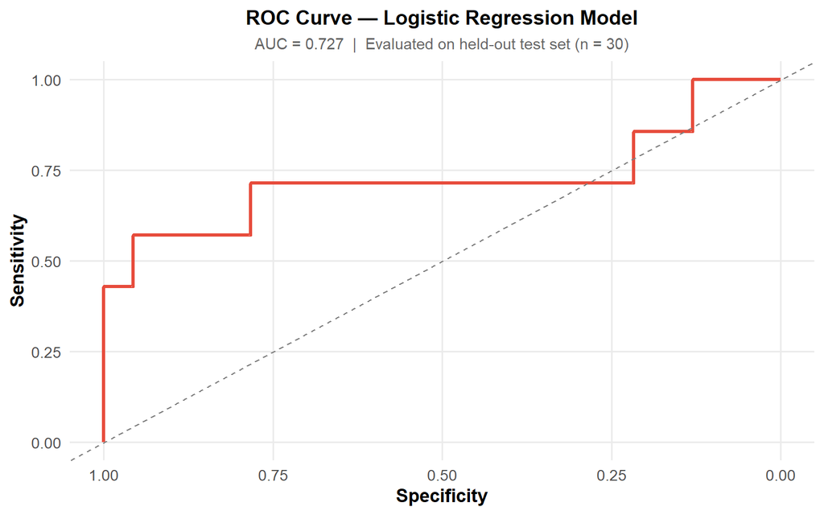

An AUC of 0.727 indicates that the model discriminates between high and low/medium engagement posts better than chance, but there remains meaningful room for improvement, particularly in identifying the minority class.

## 13 Conclusions

- `Hours.since.posted` is the most statistically significant predictor in this model: older posts tend to accumulate more likes.
- The relationship between `Followers` and `Likes` is positive but moderate, suggesting that follower count alone does not reliably predict engagement.
- The `Followers` distribution is strongly right-skewed, driven by a small number of high-follower accounts that inflate the mean.
- Posts in the highest time category show a higher proportion of high-like outcomes, consistent with the regression findings.
- Evaluated on a held-out test set, the logistic regression achieves 83.3% accuracy and AUC 0.727, outperforming a naive baseline but with recall for the high-engagement class remaining the primary performance gap.

## 14 Limitations

- **Small dataset:** With only 100 observations, model estimates are sensitive to sampling variation and results may not generalize reliably to other contexts.
- **Class imbalance:** Approximately 77% of posts fall in the low/medium engagement category, which inflates accuracy as a standalone metric and limits recall for the minority class.
- **Limited feature set:** Only two predictors are included. Additional features such as caption length, hashtag count, or posting time-of-day could improve predictive performance.
- **Single train/test split:** Performance estimates are based on one 70/30 split. Cross-validation would yield more stable evaluation at the cost of reduced interpretability at this dataset size.